# WQD7004-OCC3&RL: Group Assignment(Group 9)

# 1 Introduction

Airline satisfaction is a crucial aspect in the aviation industry as it directly impacts the loyalty and customer retention. Airline satisfaction data which is collected from Kaggle are used to conduct various analysis to understand passenger preferences in airline services. With the insights and conclusions from this analysis, we seek to improve the airline services and increase the passenger satisfaction.

The dataset can be found here: [Airline Passenger Satisfaction Dataset](https://www.kaggle.com/datasets/teejmahal20/airline-passenger-satisfaction)

# 2 Objectives

1. To determine the main factor that affects the passenger satisfaction.
2. To understand the correlation between the services provided by Airline.
3. To evaluate the performance of classification model and identify the best model in terms of accuracy.

# 3 Methodology

## 3.1 Data Understanding

It is critical for understanding data that is available for mining and avoiding unexpected problems during data preparation. In this phase, the steps involved are collecting data, describing and exploring data and lastly to verify the data quality. Further details are elaborated in each step.

### 3.1.1 Libraries

```r
# load library
library(ggcorrplot)
library(lattice)
library(stringr)
library(dplyr)
library(data.table)
library(ggplot2)
library(ggpubr)
library(tidyr)
library(ggrepel)
library(GGally)
library(vip)
library(patchwork)
library(magrittr)
library(caret)
library(devtools)
library(caTools)
library(party)
library(e1071)
library(class)
```

### 3.1.2 Airline Passenger Satisfaction Dataset

The dataset is uncleaned by modifying and removing some values, as well as replacing with inaccurate data via Microsoft Excel. The modified dataset will be used to perform data cleaning later.

```r
airline_df <- read.csv("Airline Passenger Satisfaction Dataset\\train_unclean.csv"
                       , header = TRUE
                       , stringsAsFactors = TRUE)
```

**Attributes and Dimension of the dataset**

```r
colnames(airline_df)
```

```
##  [1] "X"                                 "id"
##  [3] "Gender"                            "Customer.Type"
##  [5] "Age"                               "Type.of.Travel"
##  [7] "Class"                             "Flight.Distance"
##  [9] "Inflight.wifi.service"             "Departure.Arrival.time.convenient"
## [11] "Ease.of.Online.booking"            "Gate.location"
## [13] "Food.and.drink"                    "Online.boarding"
## [15] "Seat.comfort"                      "Inflight.entertainment"
## [17] "On.board.service"                  "Leg.room.service"
## [19] "Baggage.handling"                  "Checkin.service"
## [21] "Inflight.service"                  "Cleanliness"
## [23] "Departure.Delay.in.Minutes"        "Arrival.Delay.in.Minutes"
## [25] "satisfaction"
```

```r
dim(airline_df)
```

```
## [1] 103904     25
```

The dataset contains 24 distinct features and 103,904 entries, including information on various aspects of the flight experience, such as in-flight Wi-Fi service, online booking ease, gate location, food and drink, seat comfort, in-flight entertainment, on-board service, legroom, baggage handling, check-in service, cleanliness, passenger demographics such as gender, age, and travel type, as well as the information on departure and arrival delay times.

**First 5 rows in the dataset**

```r
head(airline_df)
```

```
##   X     id Gender     Customer.Type Age  Type.of.Travel    Class
## 1 0  70172   Male    Loyal customer  13  Personaltravel Eco Plus
## 2 1   5047   Male disloyal Customer  25  Businesstravel Business
## 3 2 110028 femALe    Loyal Customer  26 Business travel Business
## 4 3  24026 Female    Loyal Customer  25 Business travel Business
## 5 4 119299   Male    Loyal Customer  61 Business travel Business
## 6 5 111157 Female    Loyal Customer  26 Personal Travel     Ekon
##   Flight.Distance Inflight.wifi.service Departure.Arrival.time.convenient
## 1             460                   3.0                                 4
## 2             235                   3.5                                 2
## 3            1142                   2.0                                 2
## 4             562                   2.0                                 5
## 5             214                   3.0                                 3
## 6            1180                   3.5                                 4
##   Ease.of.Online.booking Gate.location Food.and.drink Online.boarding
```

[output cut: 27 more lines]

**Data Types for each attribute in the dataset**

```r
sapply(airline_df, class)
```

```
##                                 X                                id
##                         "integer"                         "integer"
##                            Gender                     Customer.Type
##                          "factor"                          "factor"
##                               Age                    Type.of.Travel
##                         "integer"                          "factor"
##                             Class                   Flight.Distance
##                          "factor"                         "integer"
##             Inflight.wifi.service Departure.Arrival.time.convenient
##                         "numeric"                         "integer"
##            Ease.of.Online.booking                     Gate.location
##                         "integer"                         "integer"
##                    Food.and.drink                   Online.boarding
##                         "numeric"                         "integer"
##                      Seat.comfort            Inflight.entertainment
##                         "integer"                         "integer"
##                  On.board.service                  Leg.room.service
##                         "integer"                         "integer"
##                  Baggage.handling                   Checkin.service
##                         "integer"                         "integer"
##                  Inflight.service                       Cleanliness
##                         "integer"                         "integer"
##        Departure.Delay.in.Minutes          Arrival.Delay.in.Minutes
##                         "integer"                         "integer"
##                      satisfaction
##                          "factor"
```

The data is composed of categorical (nominal and ordinal) and numerical (continuous) variables, which serves as a tool for understanding passenger behavior and their level of satisfaction.

**Summary of the dataset**

```r
summary(airline_df)
```

```
##        X                id            Gender                Customer.Type
##  Min.   :     0   Min.   :     1   femALe:   28   disloyal Customer:18981
##  1st Qu.: 25976   1st Qu.: 32534   Female:52699   Loyal customer   :   37
##  Median : 51952   Median : 64857   mAlE  :   49   Loyal Customer   :84886
##  Mean   : 51952   Mean   : 64924   Male  :51128
##  3rd Qu.: 77927   3rd Qu.: 97368
##  Max.   :103903   Max.   :129880
##
##       Age                Type.of.Travel       Class       Flight.Distance
##  Min.   : 7.00   Business travel:71622   Bisnes  :   34   Min.   :  31
##  1st Qu.:27.00   Businesstravel :   33   Business:49631   1st Qu.: 414
##  Median :40.00   Personal Travel:32176   Eco     :20315   Median : 843
##  Mean   :39.38   Personaltravel :   73   Eco Plus: 7494   Mean   :1189
##  3rd Qu.:51.00                           Economy :26388   3rd Qu.:1743
##  Max.   :85.00                           Ekon    :   42   Max.   :4983
##
##  Inflight.wifi.service Departure.Arrival.time.convenient Ease.of.Online.booking
##  Min.   :0.000         Min.   :0.00                      Min.   :0.000
##  1st Qu.:2.000         1st Qu.:2.00                      1st Qu.:2.000
##  Median :3.000         Median :3.00                      Median :3.000
##  Mean   :2.731         Mean   :3.06                      Mean   :2.757
##  3rd Qu.:4.000         3rd Qu.:4.00                      3rd Qu.:4.000
##  Max.   :8.000         Max.   :5.00                      Max.   :5.000
##
##  Gate.location   Food.and.drink  Online.boarding  Seat.comfort
##  Min.   :0.000   Min.   :0.000   Min.   :0.00    Min.   : 0.000
##  1st Qu.:2.000   1st Qu.:2.000   1st Qu.:2.00    1st Qu.: 2.000
##  Median :3.000   Median :3.000   Median :3.00    Median : 4.000
##  Mean   :2.977   Mean   :3.203   Mean   :3.25    Mean   : 3.443
##  3rd Qu.:4.000   3rd Qu.:4.000   3rd Qu.:4.00    3rd Qu.: 5.000
##  Max.   :5.000   Max.   :5.500   Max.   :5.00    Max.   :20.000
##
##  Inflight.entertainment On.board.service Leg.room.service Baggage.handling
##  Min.   :0.000          Min.   :0.000    Min.   :0.000    Min.   :1.000
##  1st Qu.:2.000          1st Qu.:2.000    1st Qu.:2.000    1st Qu.:3.000
##  Median :4.000          Median :4.000    Median :4.000    Median :4.000
##  Mean   :3.358          Mean   :3.382    Mean   :3.351    Mean   :3.632
##  3rd Qu.:4.000          3rd Qu.:4.000    3rd Qu.:4.000    3rd Qu.:5.000
##  Max.   :5.000          Max.   :5.000    Max.   :5.000    Max.   :5.000
##
##  Checkin.service Inflight.service  Cleanliness    Departure.Delay.in.Minutes
##  Min.   :0.000   Min.   :0.00     Min.   :0.000   Min.   :   0.00
##  1st Qu.:3.000   1st Qu.:3.00     1st Qu.:2.000   1st Qu.:   0.00
##  Median :3.000   Median :4.00     Median :3.000   Median :   0.00
##  Mean   :3.304   Mean   :3.64     Mean   :3.286   Mean   :  14.83
##  3rd Qu.:4.000   3rd Qu.:5.00     3rd Qu.:4.000   3rd Qu.:  12.00
##  Max.   :5.000   Max.   :5.00     Max.   :5.000   Max.   :1592.00
##                                                   NA's   :92
##  Arrival.Delay.in.Minutes                  satisfaction
##  Min.   :   0.00          neutral or dissatisfied:58879
##  1st Qu.:   0.00          satisfied              :45025
##  Median :   0.00
##  Mean   :  15.18
##  3rd Qu.:  13.00
##  Max.   :1584.00
##  NA's   :310
```

### 3.1.3 Data Checking

The purpose of data checking is to ensure that the data gathered is accurate, consistent, and complete to perform reliable analysis in the later stage.  
**Check duplicate data using the id attribute (unique identifier)**

```r
dim(airline_df[duplicated(airline_df$id),])[1]
```

```
## [1] 0
```

**Check missing values in each attribute**

```r
colSums(is.na(airline_df))
```

```
##                                 X                                id
##                                 0                                 0
##                            Gender                     Customer.Type
##                                 0                                 0
##                               Age                    Type.of.Travel
##                                 0                                 0
##                             Class                   Flight.Distance
##                                 0                                 0
##             Inflight.wifi.service Departure.Arrival.time.convenient
##                                 0                                 0
##            Ease.of.Online.booking                     Gate.location
##                                 0                                 0
##                    Food.and.drink                   Online.boarding
##                                 0                                 0
##                      Seat.comfort            Inflight.entertainment
##                                 0                                 0
##                  On.board.service                  Leg.room.service
##                                 0                                 0
##                  Baggage.handling                   Checkin.service
##                                 0                                 0
##                  Inflight.service                       Cleanliness
##                                 0                                 0
##        Departure.Delay.in.Minutes          Arrival.Delay.in.Minutes
##                                92                               310
##                      satisfaction
##                                 0
```

92 and 310 missing values were detected in continuous data, which are the attributes of Departure.Delay.in.Minutes and Arrival.Delay.in.Minutes respectively.

**Check distinct values in each nominal attribute**

```r
levels(airline_df$Gender)
```

```
## [1] "femALe" "Female" "mAlE"   "Male"
```

```r
levels(airline_df$Customer.Type)
```

```
## [1] "disloyal Customer" "Loyal customer"    "Loyal Customer"
```

```r
levels(airline_df$Type.of.Travel)
```

```
## [1] "Business travel" "Businesstravel"  "Personal Travel" "Personaltravel"
```

```r
levels(airline_df$Class)
```

```
## [1] "Bisnes"   "Business" "Eco"      "Eco Plus" "Economy"  "Ekon"
```

## 3.2 Data Cleaning

Having clean data will ultimately increase overall productivity and allow for the highest quality information in your decision-making. 92 and 310 missing values were detected in continuous data, which are the attributes of Departure.Delay.in.Minutes and Arrival.Delay.in.Minutes respectively and are cleaned by replacing with 0 value. Incorrect, misspell and structural error values are detected in nominal values such as Gender, Customer.Type, Type.of.Travel and Class attributes. Incorrect values are found in the ordinal type of attributes which are fixed using imputation method. All noisy data are cleaned, formatted and renamed accordingly. Irrelevant attributes are dropped to get the final clean data.

### 3.2.1 Nominal Data

**Gender**  
Convert Gender into proper case

```r
airline_df$Gender.C <-
  as.factor(str_to_title(airline_df$Gender))
levels(airline_df$Gender.C)
```

```
## [1] "Female" "Male"
```

**Customer Type**  
Convert Customer Type into proper case

```r
airline_df$Customer.Type.C <-
  as.factor(str_to_title(airline_df$Customer.Type))
levels(airline_df$Customer.Type.C)
```

```
## [1] "Disloyal Customer" "Loyal Customer"
```

**Type of Travel**  
Correct Type of Travel categories

```r
airline_df$Type.of.Travel.C <-
  ifelse(grepl('^b', airline_df$Type.of.Travel, ignore.case = TRUE),
         "Business Travel",
         "Personal Travel")
airline_df$Type.of.Travel.C <- as.factor(airline_df$Type.of.Travel.C)
levels(airline_df$Type.of.Travel.C)
```

```
## [1] "Business Travel" "Personal Travel"
```

**Class**  
Correct Class categories

```r
airline_df$Class.C <-
  ifelse(grepl('^b', airline_df$Class, ignore.case = TRUE),
         "Business", "Eco")
airline_df$Class.C <- as.factor(airline_df$Class.C)
levels(airline_df$Class.C)
```

```
## [1] "Business" "Eco"
```

### 3.2.2 Ordinal Data

All attributes with rating are considered as ordinal data.  
**Inflight Wifi Service**  
Replace ratings above 5 as NA (missing values) then impute missing values with mean excluding 0

```r
airline_df$Inflight.wifi.service.C <- airline_df$Inflight.wifi.service
airline_df$Inflight.wifi.service.C[airline_df$Inflight.wifi.service.C > 5] <- NA
airline_df$Inflight.wifi.service.C[is.na(airline_df$Inflight.wifi.service.C)] <-
  mean(airline_df$Inflight.wifi.service.C
       [airline_df$Inflight.wifi.service.C > 0]
       , na.rm = TRUE
       )
```

Convert to integer

```r
airline_df$Inflight.wifi.service.C <-
  round(airline_df$Inflight.wifi.service.C)
```

**Food and Drink**  
Replace ratings above 5 as NA (missing values) then impute missing values with mean excluding 0

```r
airline_df$Food.and.drink.C <- airline_df$Food.and.drink
airline_df$Food.and.drink.C[airline_df$Food.and.drink.C > 5] <- NA
airline_df$Food.and.drink.C[is.na(airline_df$Food.and.drink.C)] <-
  mean(airline_df$Food.and.drink.C
       [airline_df$Food.and.drink.C > 0]
       , na.rm = TRUE
       )
```

Convert to integer

```r
airline_df$Food.and.drink.C <-
  round(airline_df$Food.and.drink.C)
```

**Seat Comfort**  
Replace ratings above 5 as NA (missing values) then impute missing values with mean excluding 0

```r
airline_df$Seat.comfort.C <- airline_df$Seat.comfort
airline_df$Seat.comfort.C[airline_df$Seat.comfort.C > 5] <- NA
airline_df$Seat.comfort.C[is.na(airline_df$Seat.comfort.C)] <-
  mean(airline_df$Seat.comfort.C
       [airline_df$Seat.comfort.C > 0]
       , na.rm = TRUE
       )
```

Convert to integer

```r
# convert to integer
airline_df$Seat.comfort.C <-
  round(airline_df$Seat.comfort.C)
```

**All attributes with ratings**  
Convert all ratings attributes to ordinal data

```r
ratings <- c("Inflight.wifi.service.C", "Food.and.drink.C", "Seat.comfort.C",
          "Departure.Arrival.time.convenient",  "Ease.of.Online.booking",
          "Gate.location", "Online.boarding", "Inflight.entertainment",
          "On.board.service",   "Leg.room.service", "Baggage.handling",
          "Checkin.service",    "Inflight.service", "Cleanliness"
          )
airline_df[ratings] <- lapply(airline_df[ratings],
                              factor,
                              levels=c(0, 1, 2, 3, 4, 5)
                              )
```

### 3.2.3 Continuous Data

**Departure & Arrival Delay in minutes**  
Replace NA with 0

```r
delay_cols <- c("Departure.Delay.in.Minutes", "Arrival.Delay.in.Minutes")
airline_df[delay_cols][is.na(airline_df[delay_cols])] <- 0
```

### 3.2.4 Tidy Up

```r
# rearrange columns
col_order <- c("X", "id", "Gender", "Gender.C", "Customer.Type",
               "Customer.Type.C", "Age", "Type.of.Travel", "Type.of.Travel.C",
               "Class", "Class.C","Flight.Distance", "Inflight.wifi.service",
               "Inflight.wifi.service.C", "Departure.Arrival.time.convenient",
               "Ease.of.Online.booking", "Gate.location", "Food.and.drink",
               "Food.and.drink.C", "Online.boarding", "Seat.comfort",
               "Seat.comfort.C", "Inflight.entertainment", "On.board.service",
               "Leg.room.service", "Baggage.handling", "Checkin.service",
               "Inflight.service",  "Cleanliness", "Departure.Delay.in.Minutes",
               "Arrival.Delay.in.Minutes", "satisfaction"
               )
airline_df <- airline_df[, col_order]

# drop columns
drop_col <- c("Gender", "Customer.Type", "Type.of.Travel", "Class",
              "Inflight.wifi.service", "Food.and.drink", "Seat.comfort")
airline_df[, drop_col] <- list(NULL)

# rename columns
old_colnames <- c("Gender.C", "Customer.Type.C", "Type.of.Travel.C", "Class.C",
                  "Inflight.wifi.service.C", "Food.and.drink.C", "Seat.comfort.C"
                  )
new_colnames <- drop_col
setnames(airline_df, old = old_colnames, new = new_colnames)

# drop "X" column
airline_df[, "X"] <- list(NULL)
```

## 3.3 Exploratory Data Analysis (EDA)

### 3.3.1 Overview

In this section, we will walk through an overall view of the airline satisfaction dataset, by customer demographics and service ratings.

#### 3.3.1.1 Customers

Below graphs represent an overview of the passengers demographics and characteristics, which will be used in further analysis.

**Customer Gender**

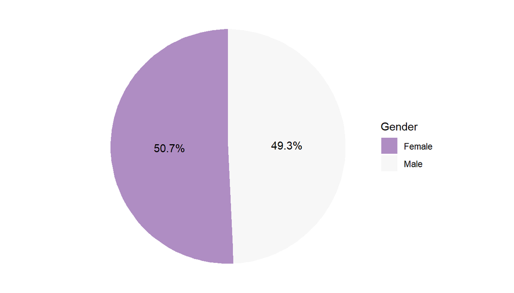

**Customer Age**

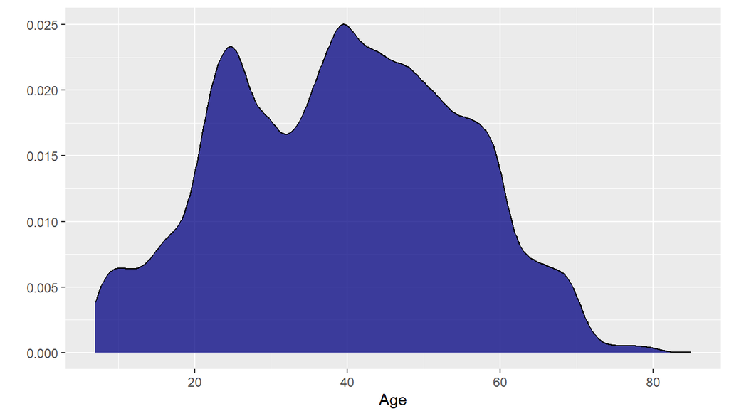

The age distribution of the passenger population shows a clear pattern of increasing numbers as age increases, peaking in the twenties range. The number then drops slightly in the thirties age range, before climbing back up to the highest peak in the forties. From there, the number of passengers gradually decreases as age increases. This pattern is clearly visible in the graph, providing an overall picture of the age distribution among the passenger population.

**Customer Type**

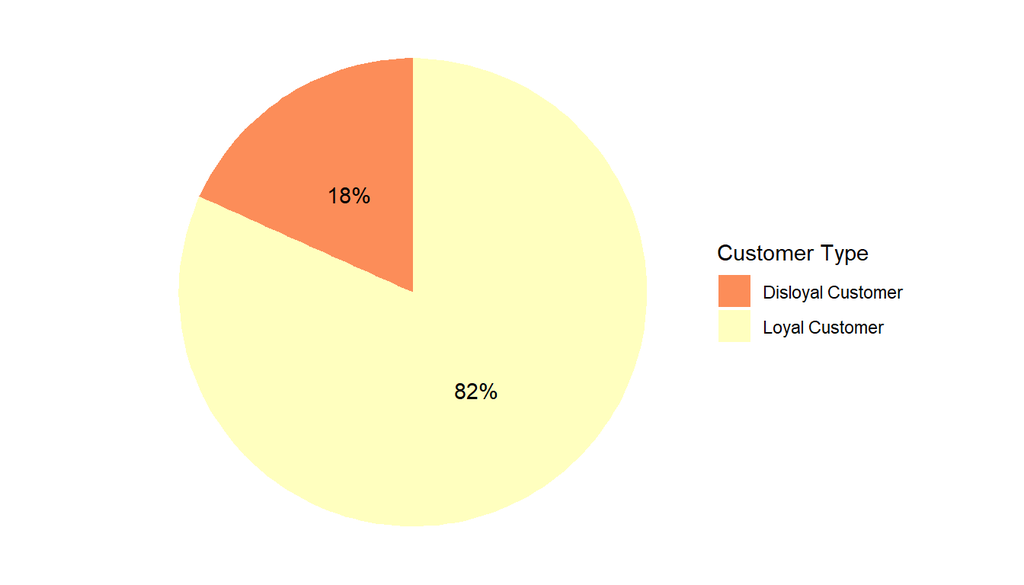

It can be observed that 18% of the customers are disloyal and 82% are loyal. This indicates that most of the customers have a history of repeat business with the company and can inform strategies to retain and attract loyal customers.

**Travel Type**

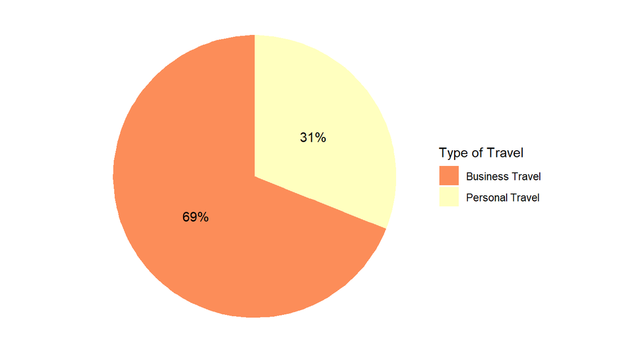

Additionally, the data shows that 69% of the customers are traveling for business purposes and 31% are traveling for personal reasons. This can provide insight into the type of customers the company is serving and can inform marketing and sales efforts to specific segments of the customer base.

**Flight Class**

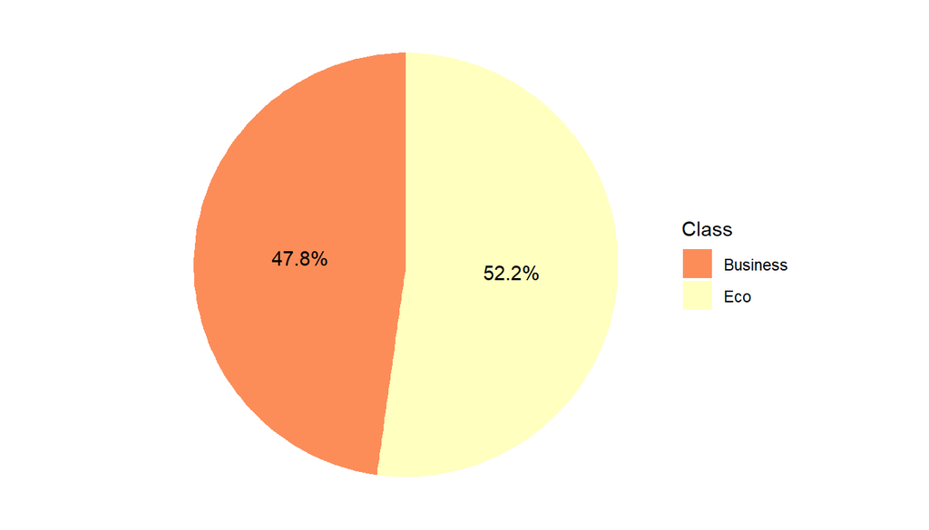

Lastly, regarding flight class, the data indicates that 47.8% of the customers are traveling in business class, 52.2% in economy class. This information can be used to understand the type of customers that are traveling in different classes, adjust pricing and inventory management strategies, and understand the revenue generated from different classes of customers.

**Flight Arrival & Delay in Minutes**

- Based on the box plot below, we can conclude that both arrival and departure delay mostly fall in the region of 0 minute to 10 minutes and with less amount of delay more than 10 minutes. Both delay are comparable to each other also.

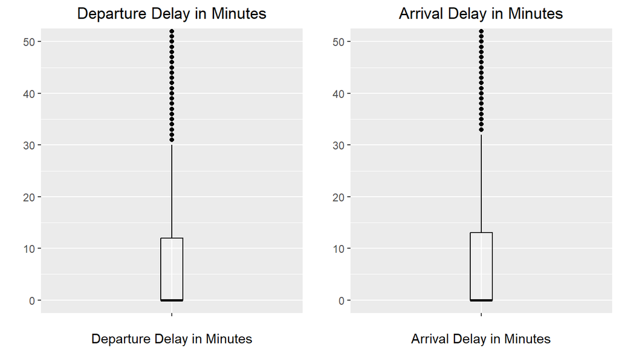

Overall, the data gives valuable insights into the customer base and can be used to inform business decisions and improve customer satisfaction. It allows the Airlines to understand the characteristics of their customers, such as loyalty, travel type and flight class, and use it to tailor their services and attract more customers.

#### 3.3.1.2 Service Ratings

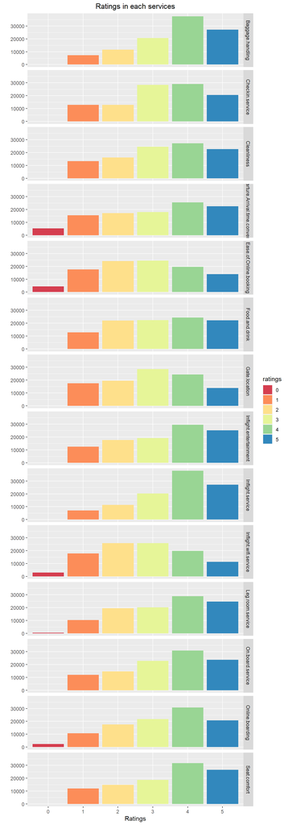

Now, we will perform analysis from different perspectives, such as customer age, customer gender, customer type, travel type and flight class.

### 3.3.2 Customer Age

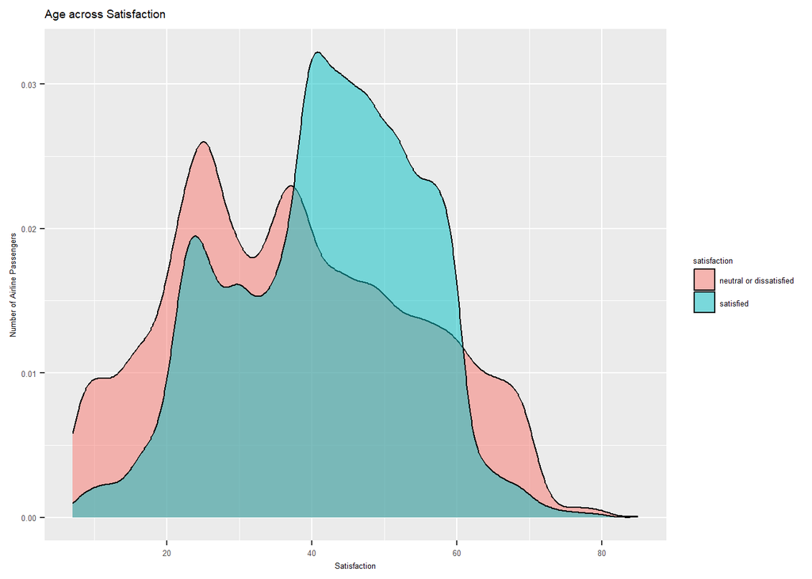

### 3.3.3 Customer Gender

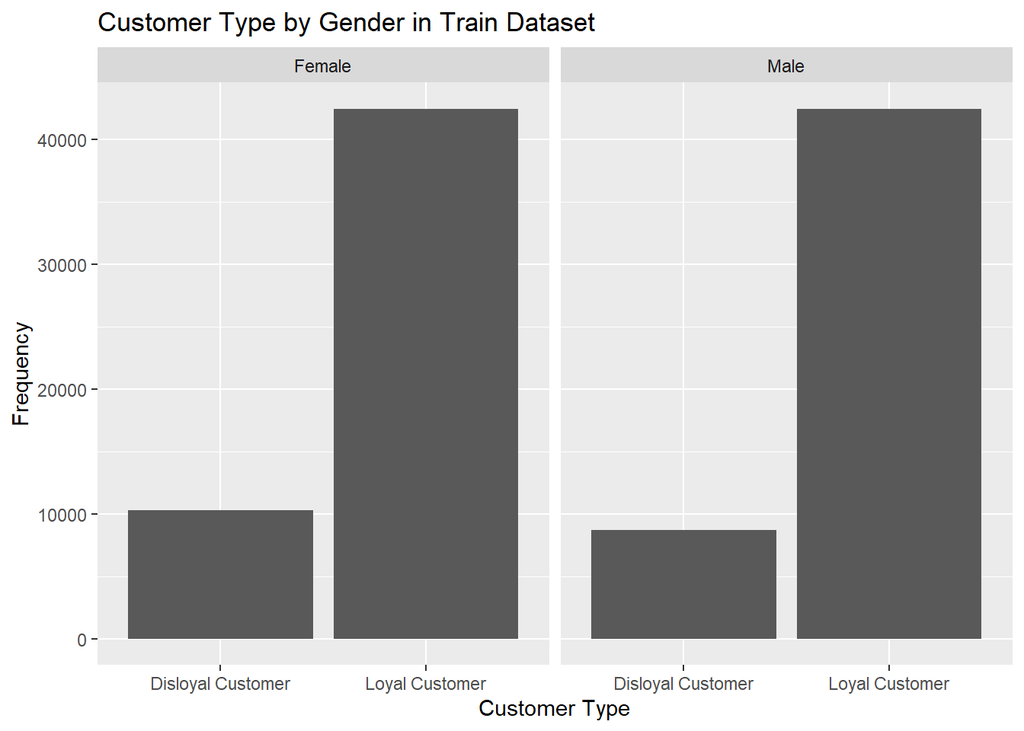

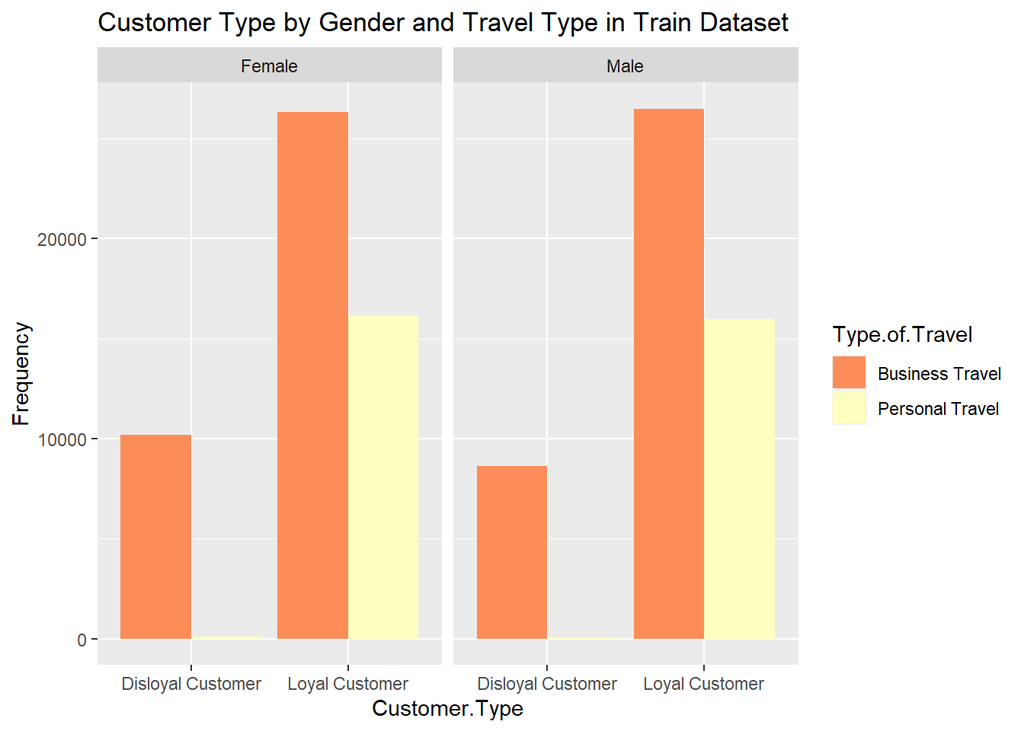

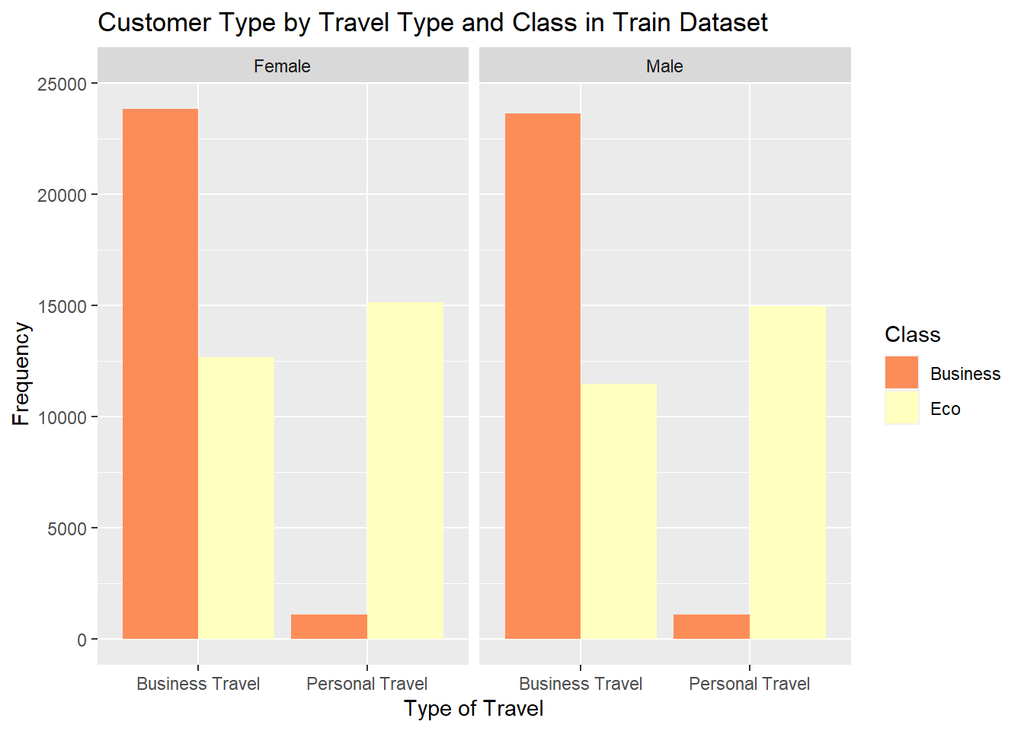

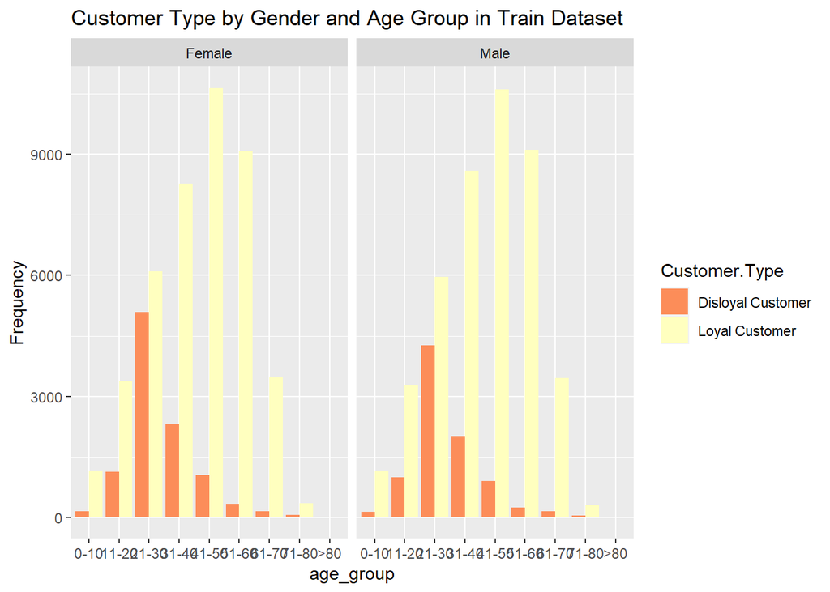

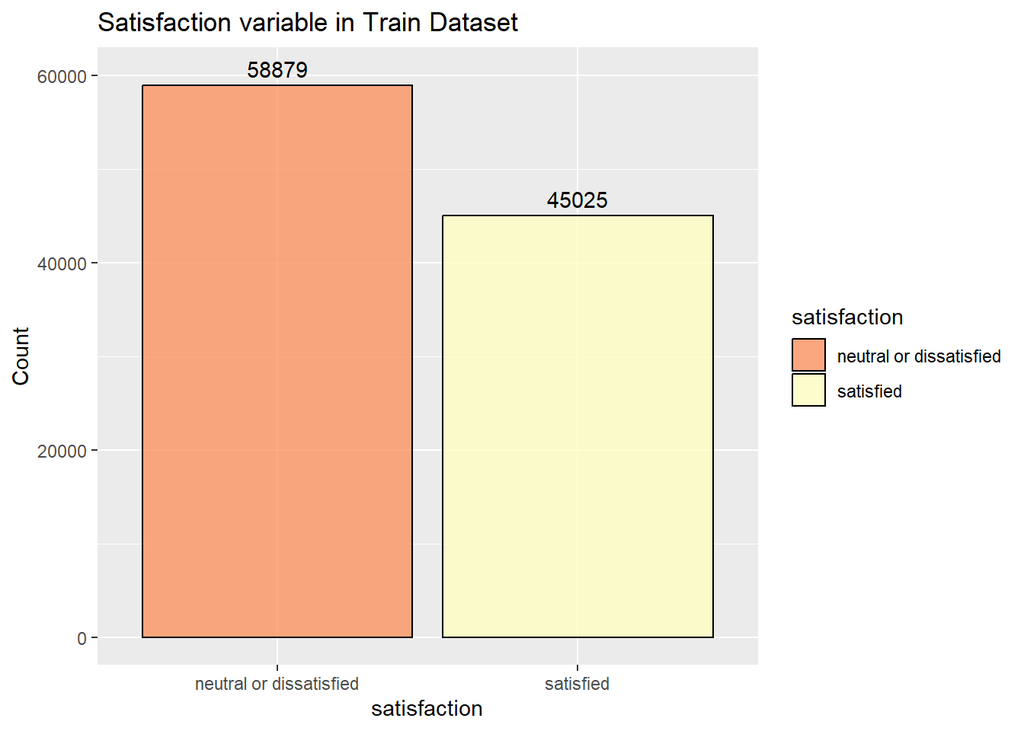

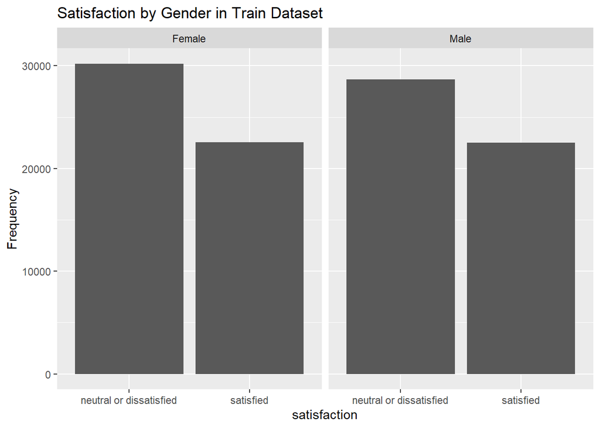

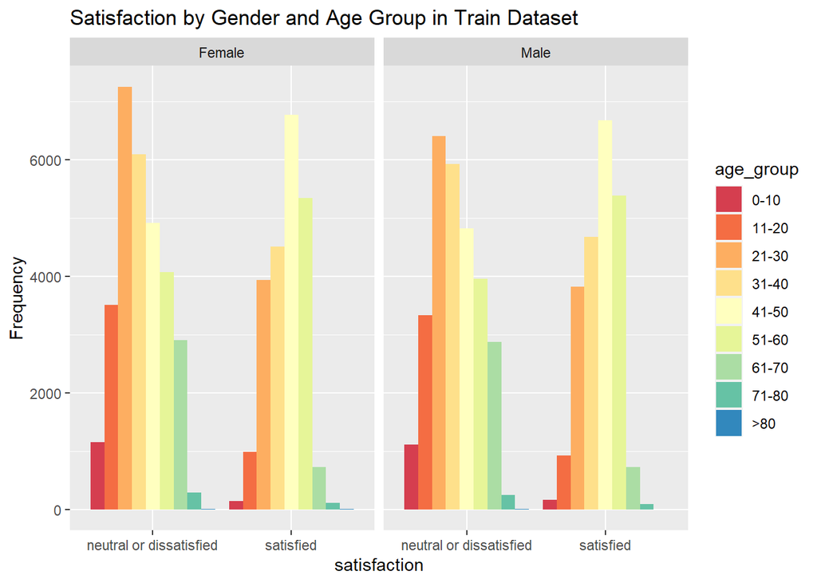

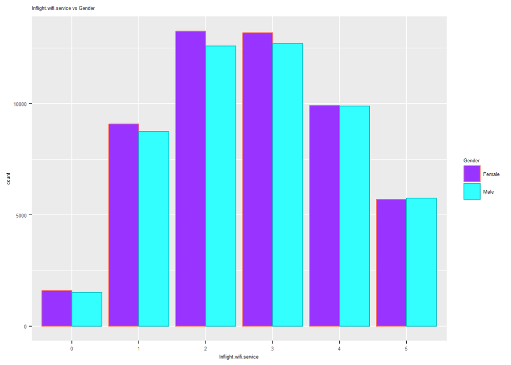

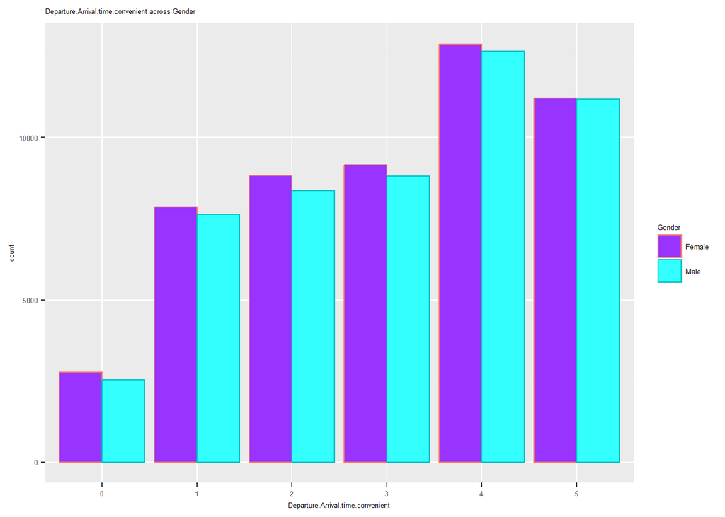

[figure not shown]

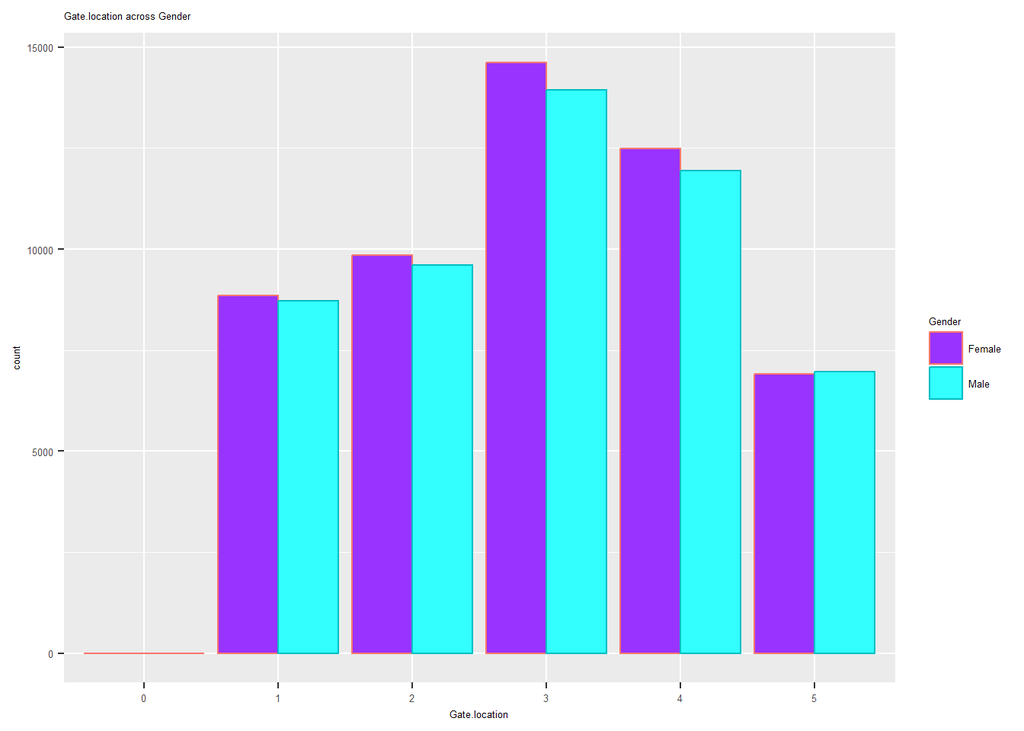

[figure not shown]

[10 more figures not shown]

### 3.3.4 Customer Type

**Different perspectives from Customer Type**

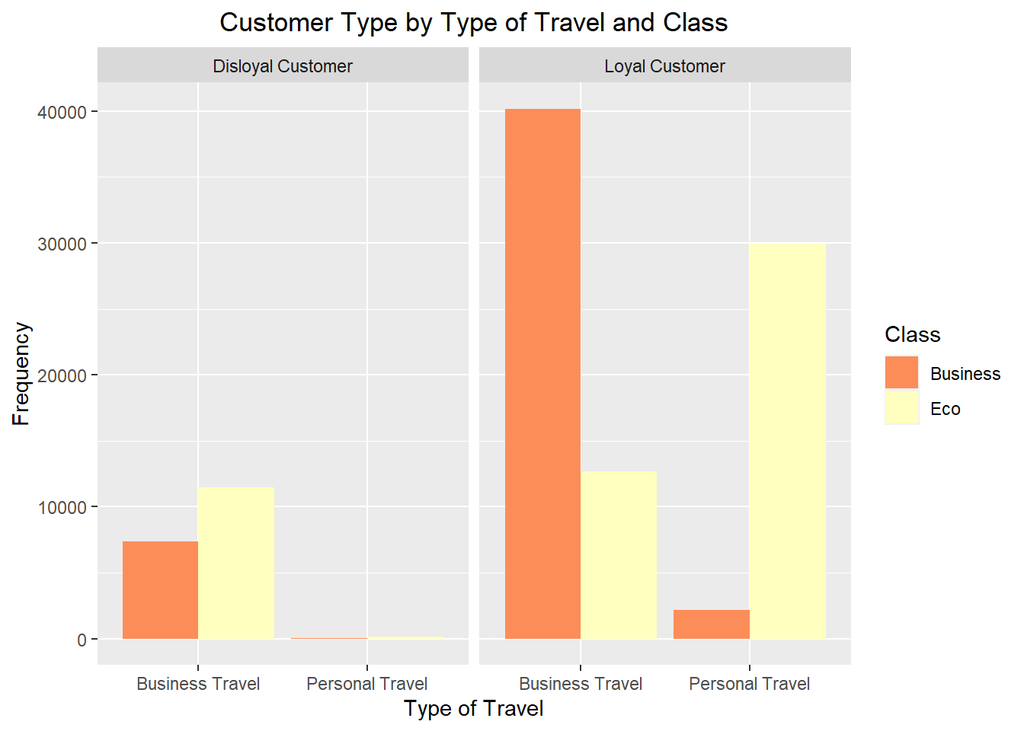

- Both customers tend to choose the airline for business travel rather than personal travel, with a more distinct distribution of travel type in the disloyal customers group.
- Disloyal customers prefer Eco class for business travel, while majority of loyal customers prefer Business class for business travel but Eco class for personal travel.

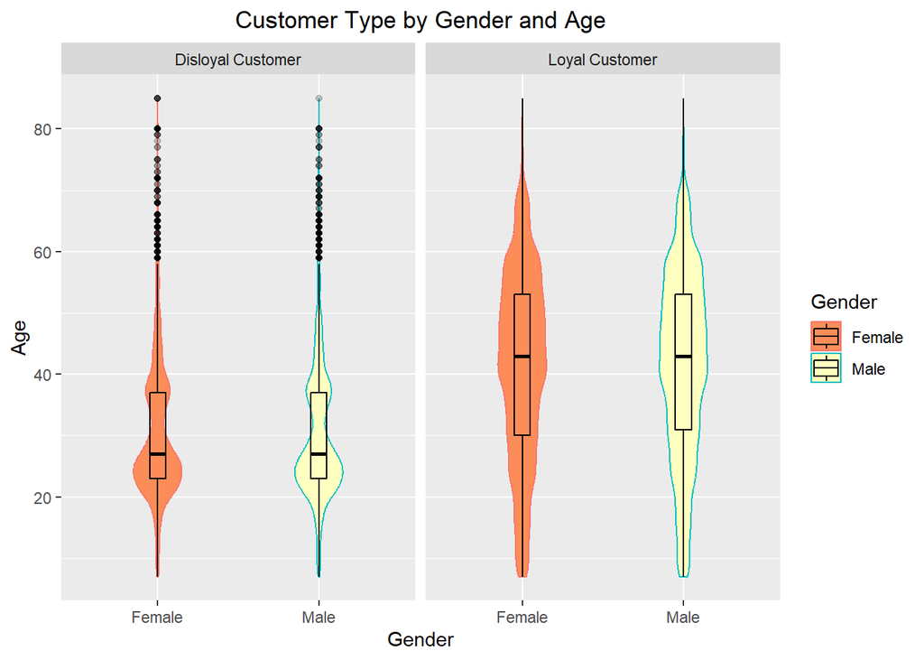

- The distribution of age for gender in each customer type is similar.
- The distribution of age for loyal and disloyal customers is unalike; widely-spread age distribution for loyal customers and non-symmetric bimodal age distribution for disloyal customers, with larger distribution in mid 20’s.
- The quartiles of the loyal customers fall between 30’s to 50’s, whereas the quartiles of disloyal customers are more concentrated at mid 20’s to near 40’s.
- Most disloyal customers are younger than loyal customers.

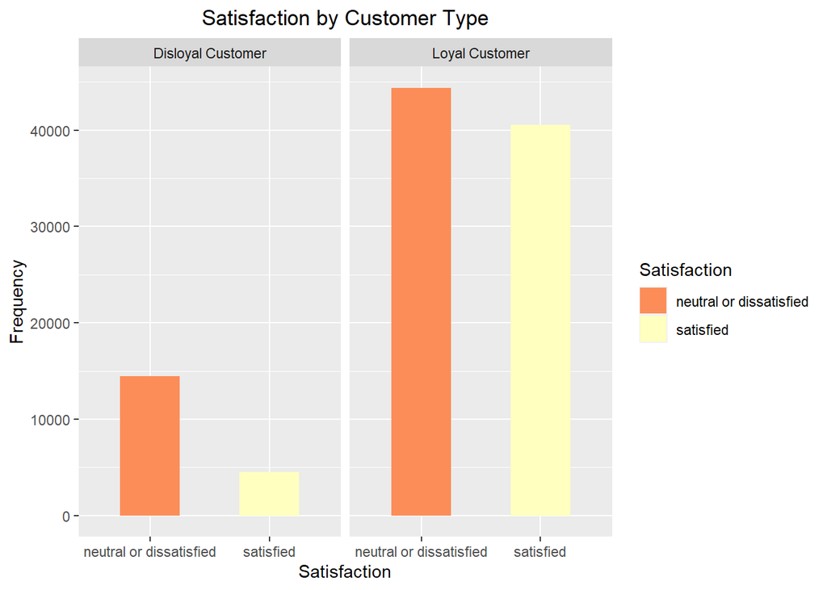

Since majority of the customers are loyal customers, hence we will focus on the ratings distribution of loyal customers. Looking into the distribution of ratings for loyal customers, most services have similar distribution of ratings in each customer type with gradually increase in the count from rating 1 to 4, peak at rating 4, and slight decrease in the rating count at rating 5. However, some services did not follow this pattern, such as ease of online booking, gate location and in-flight Wi-fi service, therefore we will focus on the distribution of ratings in these 3 services in the graphs below.

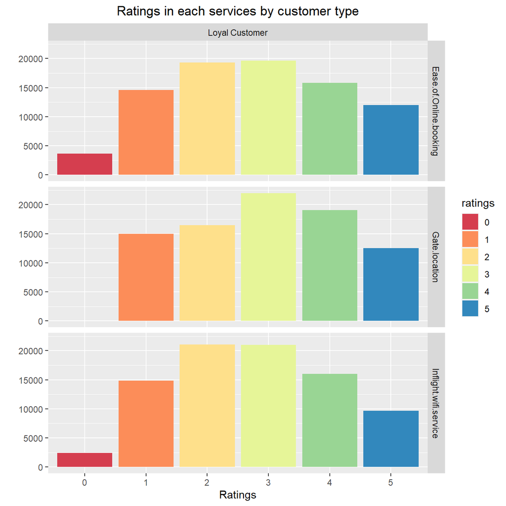

### 3.3.5 Type of Travel

**Different perspectives from Type of Travel**

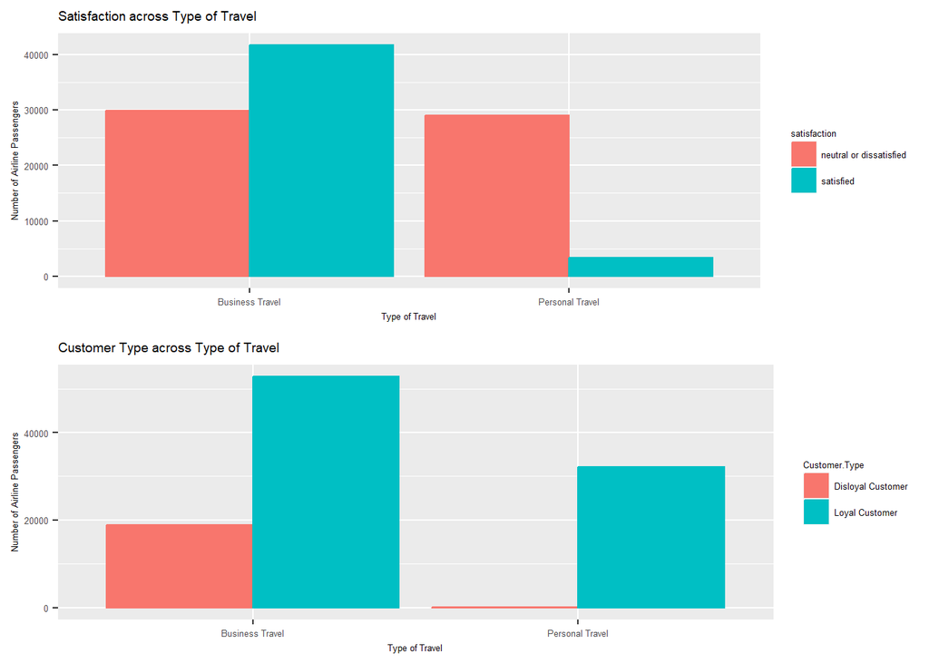

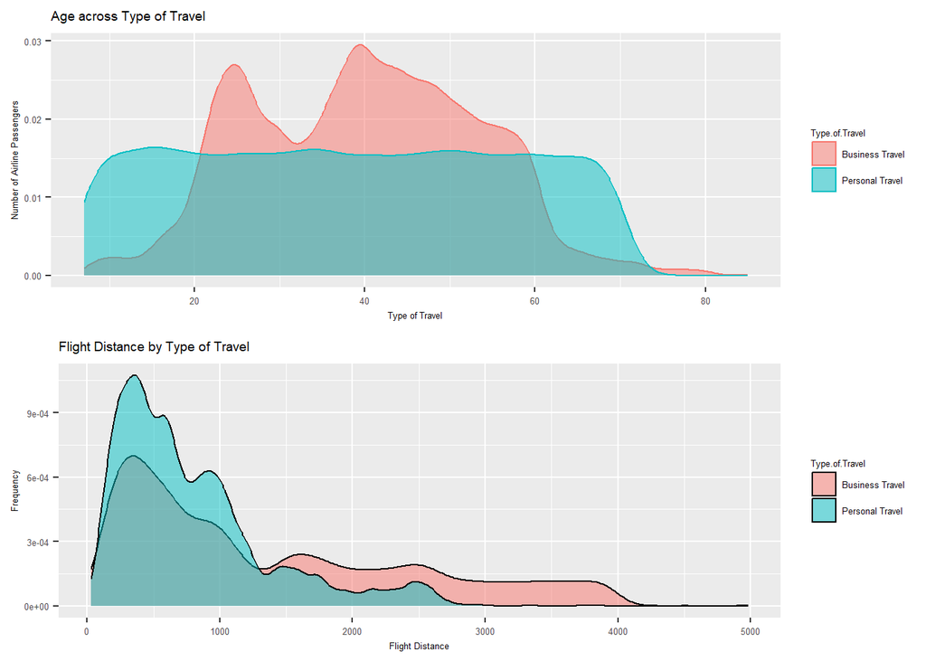

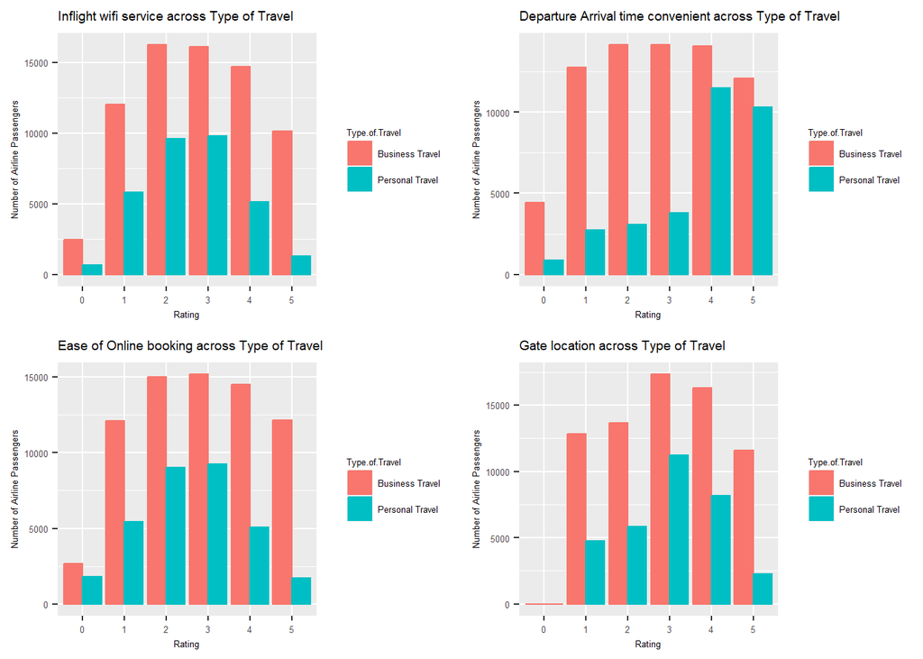

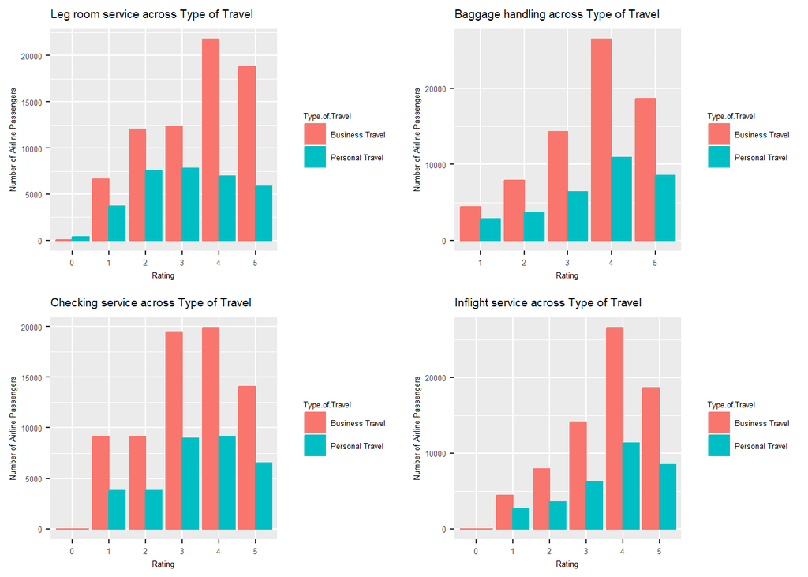

[figure not shown]